# Housing Market - Code

Anti-Code Group

11/26/2019

# 1 KNN

Here, we convert “price” to a factor variable and divide it into 3 categories (“Low”, “Medium”, and “High”) to prepare for KNN analysis.

```r
kc_house_data$price <- cut(kc_house_data$price, breaks = 3, labels = c("Low", "Medium", "High")) # categorization of house prices
summary(kc_house_data$price) # distribution of data points according to their categories
```

```
##    Low Medium   High
##  21514     76      6
```

Next, we split the data into 80% training, and 20% test subsets.

```r
set.seed(1)
kc_house_data_train_rows = sample(1:nrow(kc_house_data),     #<- from 1 to the number of
                                                     #   rows in the data set
                              round(0.8 * nrow(kc_house_data), 0),  #<- multiply the
                                                                #   number of rows
                                                                #   by 0.8 and round
                                                                #   the decimals
                              replace = FALSE)       #<- don't replace the numbers
# Let's check to make sure we have 80% of the rows.
length(kc_house_data_train_rows) / nrow(kc_house_data)
```

```
## [1] 0.8000093
```

```r
kc_house_data_train = kc_house_data[kc_house_data_train_rows, ]  #<- select the rows identified in
                                                     #   the kc_house_data_train_rows data
kc_house_data_test = kc_house_data[-kc_house_data_train_rows, ]  #<- select the rows that weren't
                                                     #   identified in the
                                                     #   kc_house_data_train_rows data
```

We then apply the chooseK() function to determine the best KNN k value for our dataset. Within the chooseK() function itself, I select features that are truly numeric (KNN requires predictor variables to be numeric). For instance, even though “yr_built” is classified as an “integer” data type, a concept such as year is best thought of as categorical, not numerical. As a result, I chose to exclude this and other similar variables from the analysis.

```
##  num [1:2, 1:13] 1 0.994 3 0.996 5 ...
```

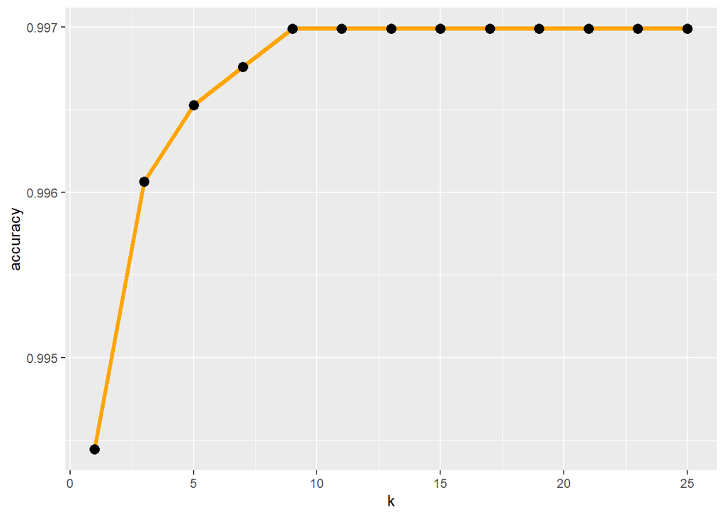

```r
# Let's train the classifier for k = 5
# Install the "class" package that we'll use to run kNN.
# Take some time to learn about all its functionality.
# install.packages("class")
loadPkg("class")
# k-Nearest Neighbor is a randomized algorithm, so make sure to
# use set.seed() to make your results repeatable.
set.seed(1)
price_predict = knn(train = kc_house_data_train[, c("bedrooms", "bathrooms", "sqft_living", "sqft_lot", "floors", "sqft_above", "sqft_basement", "sqft_living15", "sqft_lot15")],  #<- training set cases
               test = kc_house_data_test[, c("bedrooms", "bathrooms", "sqft_living", "sqft_lot", "floors", "sqft_above", "sqft_basement", "sqft_living15", "sqft_lot15")],    #<- test set cases
               cl = kc_house_data_train[, "price"],                         #<- category for true classification
               k = 5) #,                                                    #<- number of neighbors considered
               # use.all = TRUE)                                            #<- control ties between class assignments
                                                                            #   If true, all distances equal to the kth
                                                                            #   largest are included
# View the output.
str(price_predict)
```

```
##  Factor w/ 3 levels "Low","Medium",..: 1 1 1 1 1 1 1 1 1 1 ...
```

```r
length(price_predict)
```

```
## [1] 4319
```

```r
table(price_predict)
```

```
## price_predict
##    Low Medium   High
##   4317      2      0
```

```r
# How does the kNN classification compare to the true class?
# Let's take a look at the confusion matrix by combining the
# predictions from price_predict to the original data set.
kNN_res = table(price_predict,
                kc_house_data_test$`price`)
kNN_res
```

```
##
## price_predict  Low Medium High
##        Low    4304     11    2
##        Medium    2      0    0
##        High      0      0    0
```

```r
sum(kNN_res)  #<- the total is all the test examples
```

```
## [1] 4319
```

```r
# Select the true positives and true negatives by selecting
# only the cells where the row and column names are the same.
kNN_res[row(kNN_res) == col(kNN_res)]
```

```
## [1] 4304    0    0
```

```r
# Calculate the accuracy rate by dividing the correct classifications
# by the total number of classifications.
kNN_acc = sum(kNN_res[row(kNN_res) == col(kNN_res)]) / sum(kNN_res)
kNN_acc
```

```
## [1] 0.996527
```

# 2 Trees

## 2.1 Loading Data and Clean

https://www.kaggle.com/harlfoxem/housesalesprediction/data

https://github.com/matteobucalossi50/DATS6101_Project

```
## 'data.frame':    21613 obs. of  21 variables:
##  $ id           : num  7129300520 6414100192 5631500400 2487200875 1954400510 ...
##  $ date         : Factor w/ 372 levels "20140502T000000",..: 165 221 291 221 284 11 57 252 340 306 ...
##  $ price        : num  221900 538000 180000 604000 510000 ...
##  $ bedrooms     : int  3 3 2 4 3 4 3 3 3 3 ...
##  $ bathrooms    : num  1 2.25 1 3 2 4.5 2.25 1.5 1 2.5 ...
##  $ sqft_living  : int  1180 2570 770 1960 1680 5420 1715 1060 1780 1890 ...
##  $ sqft_lot     : int  5650 7242 10000 5000 8080 101930 6819 9711 7470 6560 ...
##  $ floors       : num  1 2 1 1 1 1 2 1 1 2 ...
##  $ waterfront   : int  0 0 0 0 0 0 0 0 0 0 ...
##  $ view         : int  0 0 0 0 0 0 0 0 0 0 ...
##  $ condition    : int  3 3 3 5 3 3 3 3 3 3 ...
##  $ grade        : int  7 7 6 7 8 11 7 7 7 7 ...
##  $ sqft_above   : int  1180 2170 770 1050 1680 3890 1715 1060 1050 1890 ...
##  $ sqft_basement: int  0 400 0 910 0 1530 0 0 730 0 ...
##  $ yr_built     : int  1955 1951 1933 1965 1987 2001 1995 1963 1960 2003 ...
##  $ yr_renovated : int  0 1991 0 0 0 0 0 0 0 0 ...
##  $ zipcode      : int  98178 98125 98028 98136 98074 98053 98003 98198 98146 98038 ...
##  $ lat          : num  47.5 47.7 47.7 47.5 47.6 ...
##  $ long         : num  -122 -122 -122 -122 -122 ...
##  $ sqft_living15: int  1340 1690 2720 1360 1800 4760 2238 1650 1780 2390 ...
##  $ sqft_lot15   : int  5650 7639 8062 5000 7503 101930 6819 9711 8113 7570 ...
```

## 2.2 Regression Tree

```
##
## Regression tree:
## tree(formula = log(price) ~ bedrooms + bathrooms + sqft_living +
##     sqft_lot + floors + condition + grade + sqft_above + sqft_basement +
##     yr_built + yr_renovated, data = kc_house_data)
## Variables actually used in tree construction:
## [1] "grade"       "yr_built"    "sqft_living"
## Number of terminal nodes:  9
## Residual mean deviance:  0.1201 = 2594 / 21590
## Distribution of residuals:
##      Min.   1st Qu.    Median      Mean   3rd Qu.      Max.
## -1.604000 -0.231800  0.005617  0.000000  0.226800  1.788000
```

The tree built on all the features used as predictors (namely excluding id, date, geographic variables and sqft_living15 and sqft_lot15) for price, presents 9 termindal nodes and a mean squared error of 0.12.

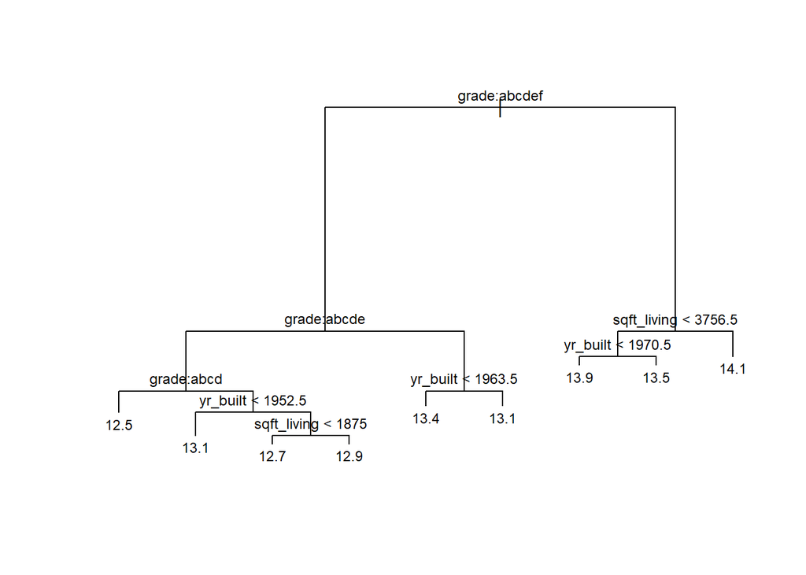

We can see that the algorithm splits the data using grade, yr_built and sqft_living. As expected, if grade is better and sqft_living are larger, price would be higher. While if grade is lower and houses get older and smaller, price would then be likely lower. As we used the log of price to predict price with this tree, we can see how the highest average of price in the farthest right leaf is 1289802.9335781 dollars and the lowest average of price in the farthest left is 273758.0592877 dollars.

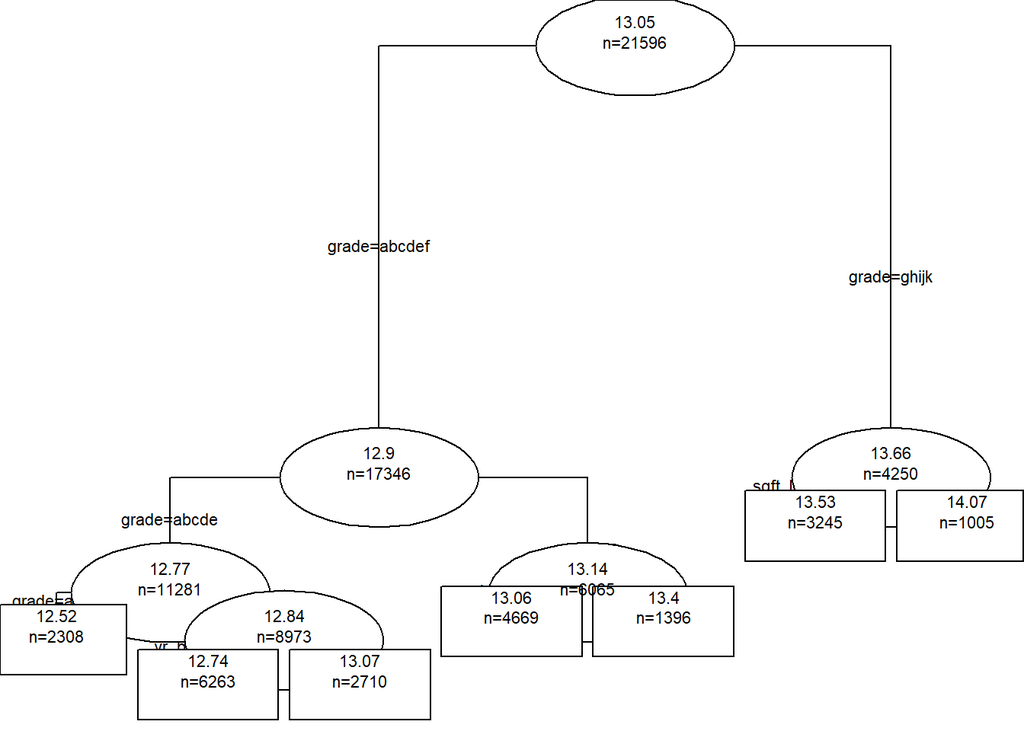

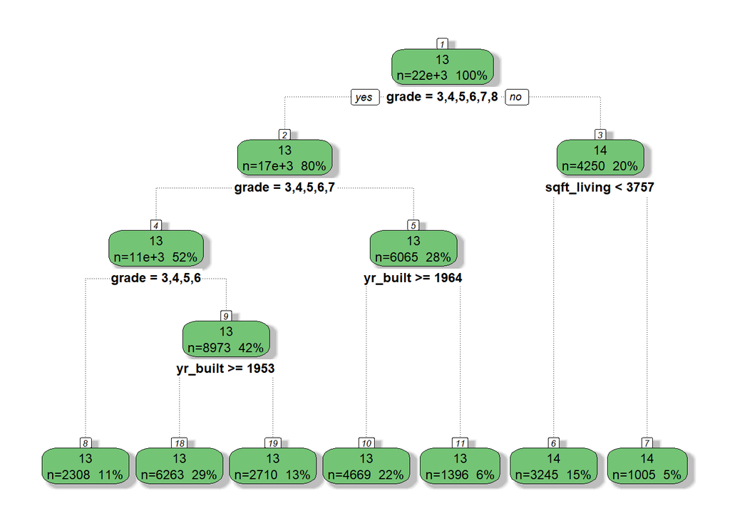

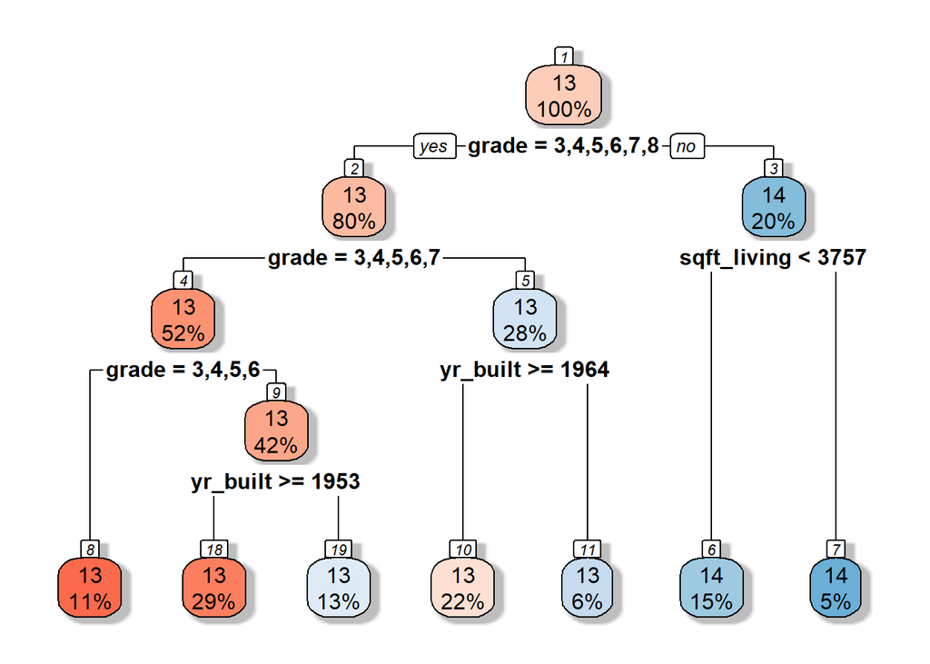

Using the package rpart, we can build a tree that provides a similar result but from which we can observe the proportion of sample observations present in each terminal leaf (in this case 7). As expected, the right branches of the tree only contain 20% of the houses, while the largest proportion are on the left branches given their lower price.

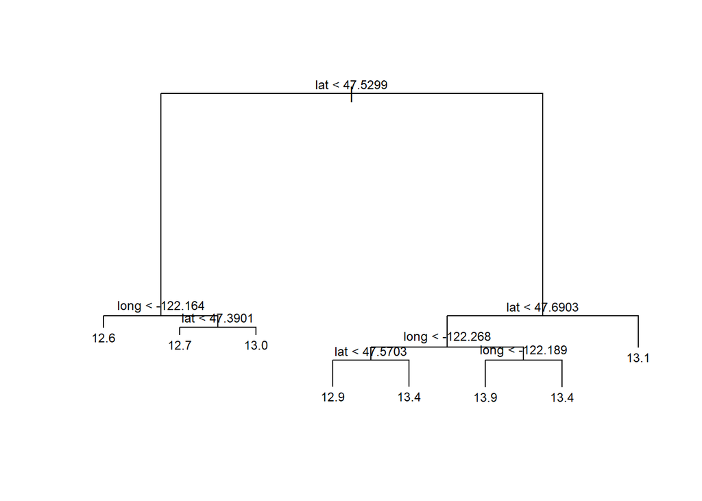

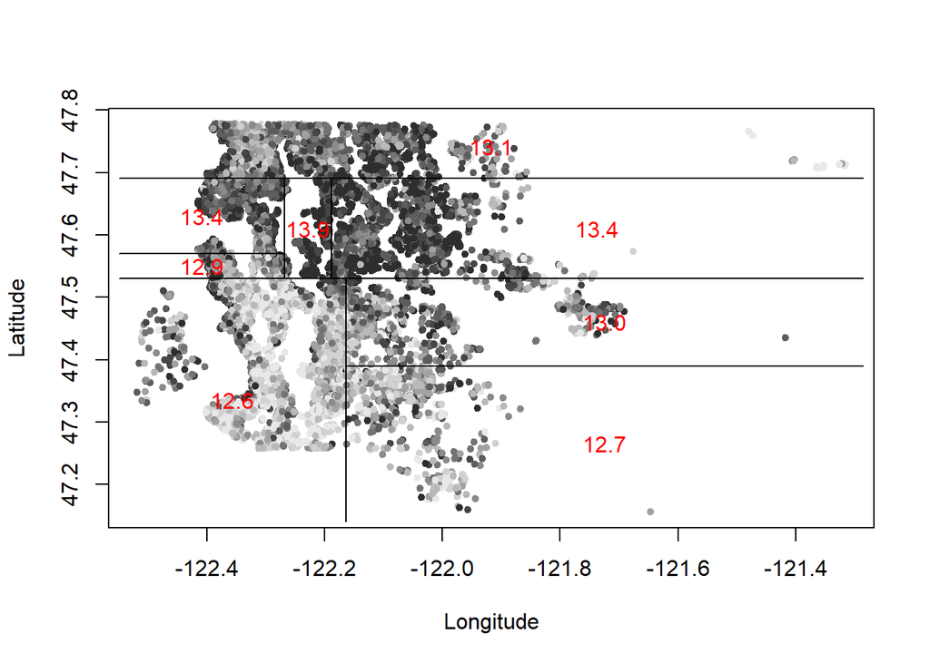

## 2.3 Prune tree

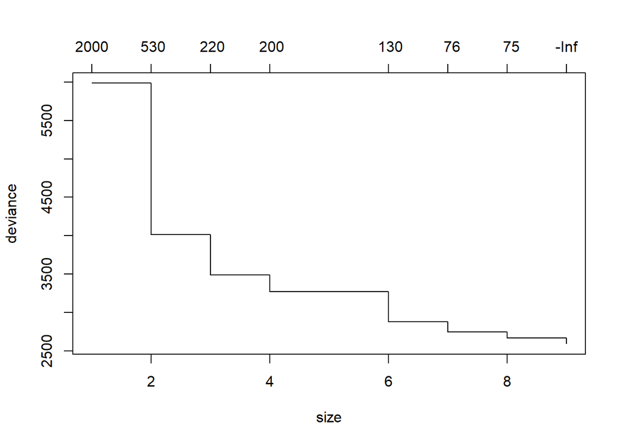

```
## [1] 2593.610 2668.388 2744.880 2875.801 3268.008 3489.958 4016.003 5984.489
```

```
## [1] 9
```

```
## node), split, n, deviance, yval
##       * denotes terminal node
##
##  1) root 21596 5984.0 13.05
##    2) grade: 3,4,5,6,7,8 17346 3119.0 12.90
##      4) grade: 3,4,5,6,7 11281 1785.0 12.77
##        8) grade: 3,4,5,6 2308  366.8 12.52 *
##        9) grade: 7 8973 1230.0 12.84
##         18) yr_built < 1952.5 2710  335.8 13.07 *
##         19) yr_built > 1952.5 6263  690.6 12.74 *
##      5) grade: 8 6065  807.9 13.14 *
##    3) grade: 9,10,11,12,13 4250  896.6 13.66
##      6) sqft_living < 3756.5 3245  456.3 13.53 *
##      7) sqft_living > 3756.5 1005  218.4 14.07 *
```

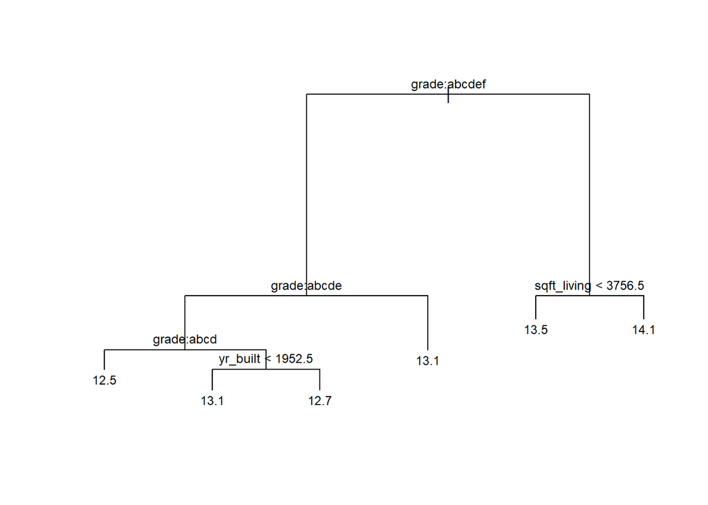

Plotting the error versus the size of trees, we can see that the optimal pruned tree (smallest tree minimizing the errors) would have 9 nodes.

## 2.4 Testing model

```
## node), split, n, deviance, yval
##       * denotes terminal node
##
##  1) root 19407 5369.0 13.04
##    2) grade: 3,4,5,6,7,8 15615 2799.0 12.90
##      4) grade: 3,4,5,6,7 10157 1602.0 12.77
##        8) grade: 3,4,5,6 2098  331.2 12.51 *
##        9) grade: 7 8059 1097.0 12.84
##         18) yr_built < 1952.5 2438  296.0 13.06 *
##         19) yr_built > 1952.5 5621  618.4 12.74 *
##      5) grade: 8 5458  725.9 13.13 *
##    3) grade: 9,10,11,12,13 3792  801.6 13.66
##      6) sqft_living < 3756.5 2900  405.8 13.53 *
##      7) sqft_living > 3756.5 892  195.4 14.07 *
```

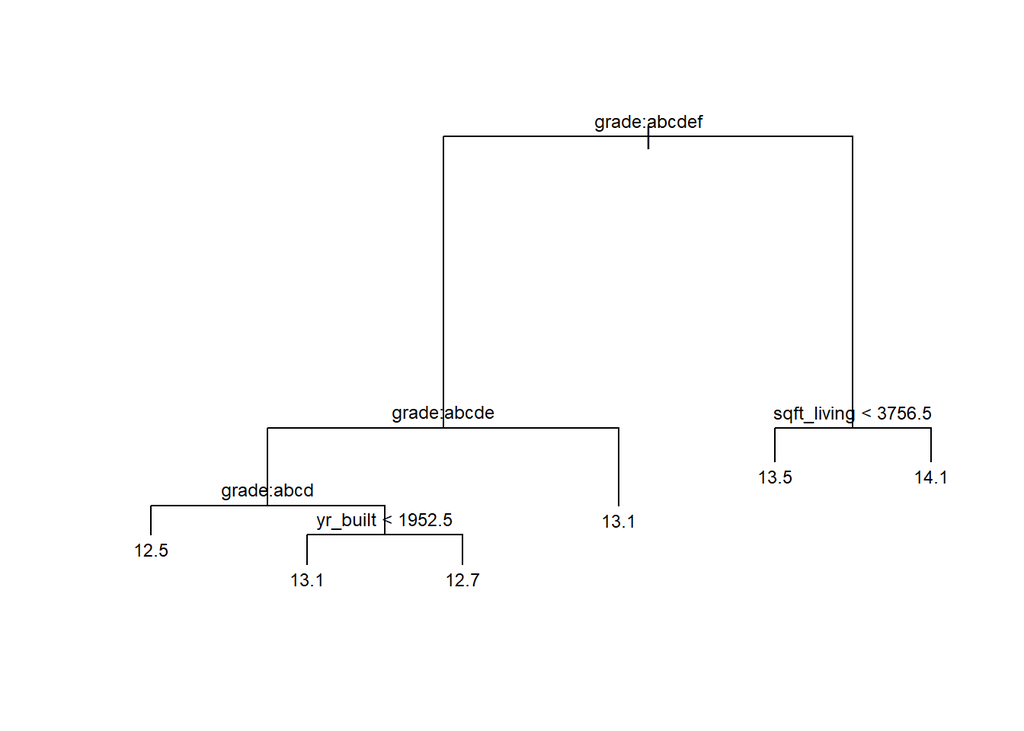

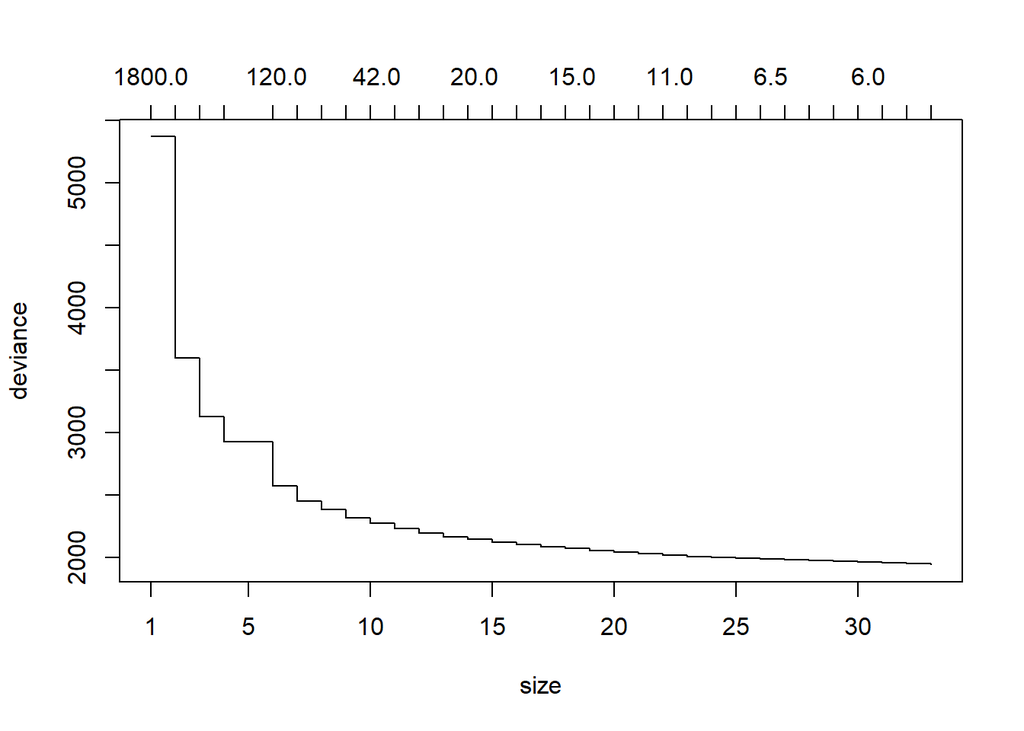

```
##  [1] 1946.642 1952.133 1957.698 1963.726 1969.807 1976.022 1982.284
##  [8] 1988.785 1995.413 2002.239 2010.535 2021.995 2033.489 2045.212
## [15] 2059.032 2073.701 2090.003 2107.529 2127.110 2147.066 2169.891
## [22] 2198.695 2233.077 2274.583 2319.417 2385.708 2454.115 2572.633
## [29] 2929.085 3129.497 3600.431 5368.966
```

```
## [1] 33
```

```
## node), split, n, deviance, yval
##       * denotes terminal node
##
##  1) root 19407 5369.0 13.04
##    2) grade: 3,4,5,6,7,8 15615 2799.0 12.90
##      4) grade: 3,4,5,6,7 10157 1602.0 12.77
##        8) grade: 3,4,5,6 2098  331.2 12.51 *
##        9) grade: 7 8059 1097.0 12.84
##         18) yr_built < 1952.5 2438  296.0 13.06 *
##         19) yr_built > 1952.5 5621  618.4 12.74 *
##      5) grade: 8 5458  725.9 13.13 *
##    3) grade: 9,10,11,12,13 3792  801.6 13.66
##      6) sqft_living < 3756.5 2900  405.8 13.53 *
##      7) sqft_living > 3756.5 892  195.4 14.07 *
```

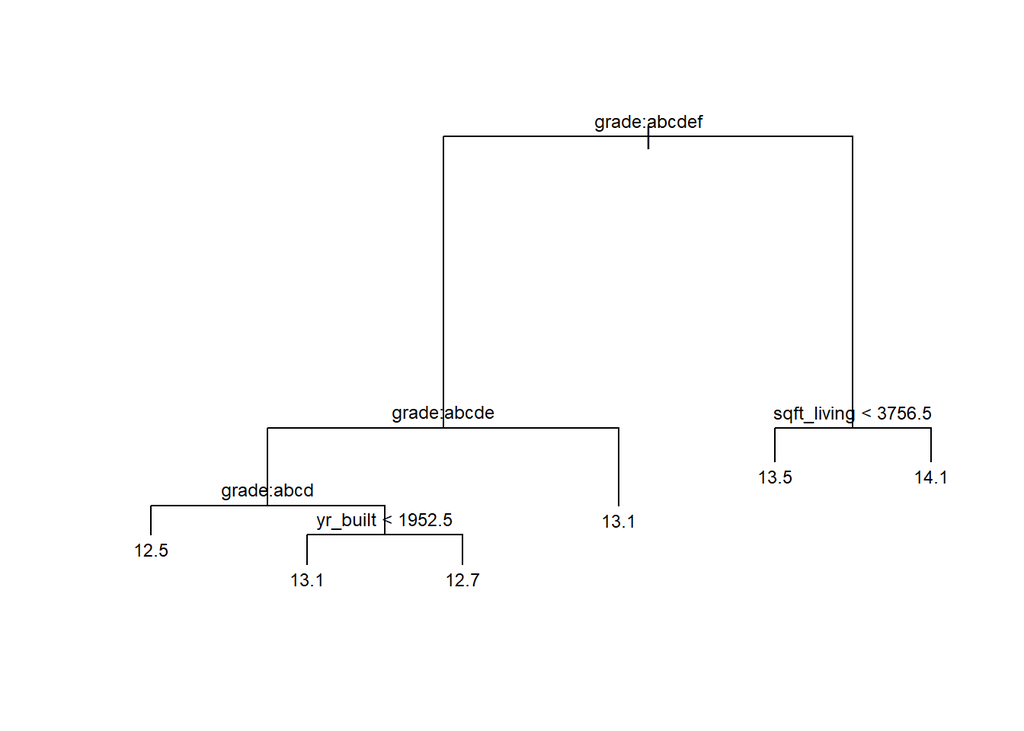

Evaluating this tree on test data, we can see how the trained model did a good job at predicting price for the dataset as errors and tree are almost identical.

# 3 Random Forest

```
##
## Call:
##  randomForest(formula = log(price) ~ bedrooms + bathrooms + sqft_living +      sqft_lot + floors + condition + grade + sqft_above + sqft_basement +      yr_built + yr_renovated, data = train.set, importance = TRUE)
##                Type of random forest: regression
##                      Number of trees: 500
## No. of variables tried at each split: 3
##
##           Mean of squared residuals: 0.08808135
##                     % Var explained: 68.16
```

# 4 PCA

##Use principle component analysis to predict the house price. Choosing this method because there are too many variables and I did not know which one to use so I want to capture as most as possible information by the least variables.

##Firstly， I loaded the dataset into Rstudio, renamed it to house and took a look at the structure of the dataset.

```
## 'data.frame':    21613 obs. of  21 variables:
##  $ id           : num  7129300520 6414100192 5631500400 2487200875 1954400510 ...
##  $ date         : Factor w/ 372 levels "20140502T000000",..: 165 221 291 221 284 11 57 252 340 306 ...
##  $ price        : num  221900 538000 180000 604000 510000 ...
##  $ bedrooms     : int  3 3 2 4 3 4 3 3 3 3 ...
##  $ bathrooms    : num  1 2.25 1 3 2 4.5 2.25 1.5 1 2.5 ...
##  $ sqft_living  : int  1180 2570 770 1960 1680 5420 1715 1060 1780 1890 ...
##  $ sqft_lot     : int  5650 7242 10000 5000 8080 101930 6819 9711 7470 6560 ...
##  $ floors       : num  1 2 1 1 1 1 2 1 1 2 ...
##  $ waterfront   : int  0 0 0 0 0 0 0 0 0 0 ...
##  $ view         : int  0 0 0 0 0 0 0 0 0 0 ...
##  $ condition    : int  3 3 3 5 3 3 3 3 3 3 ...
##  $ grade        : int  7 7 6 7 8 11 7 7 7 7 ...
##  $ sqft_above   : int  1180 2170 770 1050 1680 3890 1715 1060 1050 1890 ...
##  $ sqft_basement: int  0 400 0 910 0 1530 0 0 730 0 ...
##  $ yr_built     : int  1955 1951 1933 1965 1987 2001 1995 1963 1960 2003 ...
##  $ yr_renovated : int  0 1991 0 0 0 0 0 0 0 0 ...
##  $ zipcode      : int  98178 98125 98028 98136 98074 98053 98003 98198 98146 98038 ...
##  $ lat          : num  47.5 47.7 47.7 47.5 47.6 ...
##  $ long         : num  -122 -122 -122 -122 -122 ...
##  $ sqft_living15: int  1340 1690 2720 1360 1800 4760 2238 1650 1780 2390 ...
##  $ sqft_lot15   : int  5650 7639 8062 5000 7503 101930 6819 9711 8113 7570 ...
```

##There are 21613 oberservations on 21 variables.

##subset data ##I delete some unuseful variables which I think are uncorrelated to the house price like lattitude, longitude, the 15 neighborhoods’ sqft_living , sqft_lot, the year of renovated, zipcode, date of record, id. Also there are serveral variables contain mostly 0 values so I also deleted them like view and waterfront. And then took a look at the dataset

```
## 'data.frame':    21613 obs. of  11 variables:
##  $ price        : num  221900 538000 180000 604000 510000 ...
##  $ bedrooms     : int  3 3 2 4 3 4 3 3 3 3 ...
##  $ bathrooms    : num  1 2.25 1 3 2 4.5 2.25 1.5 1 2.5 ...
##  $ sqft_living  : int  1180 2570 770 1960 1680 5420 1715 1060 1780 1890 ...
##  $ sqft_lot     : int  5650 7242 10000 5000 8080 101930 6819 9711 7470 6560 ...
##  $ floors       : num  1 2 1 1 1 1 2 1 1 2 ...
##  $ condition    : int  3 3 3 5 3 3 3 3 3 3 ...
##  $ grade        : int  7 7 6 7 8 11 7 7 7 7 ...
##  $ sqft_above   : int  1180 2170 770 1050 1680 3890 1715 1060 1050 1890 ...
##  $ sqft_basement: int  0 400 0 910 0 1530 0 0 730 0 ...
##  $ yr_built     : int  1955 1951 1933 1965 1987 2001 1995 1963 1960 2003 ...
```

##There are 11 variables left and one variable is house which will be used as independent variable and all variables are numeric.

##Check if there are NA values.

```
## [1] 0
```

##There is no NA values.

```
##                 bedrooms   bathrooms sqft_living     sqft_lot       floors
## bedrooms      1.00000000  0.51588364  0.57667069  0.031703243  0.175428935
## bathrooms     0.51588364  1.00000000  0.75466528  0.087739662  0.500653173
## sqft_living   0.57667069  0.75466528  1.00000000  0.172825661  0.353949290
## sqft_lot      0.03170324  0.08773966  0.17282566  1.000000000 -0.005200991
## floors        0.17542894  0.50065317  0.35394929 -0.005200991  1.000000000
## condition     0.02847210 -0.12498193 -0.05875259 -0.008958250 -0.263767946
## grade         0.35696673  0.66498253  0.76270448  0.113621124  0.458182514
## sqft_above    0.47760016  0.68534248  0.87659660  0.183512281  0.523884710
## sqft_basement 0.30309338  0.28377003  0.43504297  0.015286202 -0.245704542
## yr_built      0.15417807  0.50601944  0.31804877  0.053080367  0.489319425
##                 condition      grade  sqft_above sqft_basement    yr_built
## bedrooms       0.02847210  0.3569667  0.47760016    0.30309338  0.15417807
## bathrooms     -0.12498193  0.6649825  0.68534248    0.28377003  0.50601944
## sqft_living   -0.05875259  0.7627045  0.87659660    0.43504297  0.31804877
## sqft_lot      -0.00895825  0.1136211  0.18351228    0.01528620  0.05308037
## floors        -0.26376795  0.4581825  0.52388471   -0.24570454  0.48931942
## condition      1.00000000 -0.1446737 -0.15821362    0.17410491 -0.36141656
## grade         -0.14467367  1.0000000  0.75592294    0.16839182  0.44696320
## sqft_above    -0.15821362  0.7559229  1.00000000   -0.05194331  0.42389835
## sqft_basement  0.17410491  0.1683918 -0.05194331    1.00000000 -0.13312410
## yr_built      -0.36141656  0.4469632  0.42389835   -0.13312410  1.00000000
```

##Took a look at the correlation of the 10 dependent variables and I found that they are all related, some ones are highly related. It shows me that very hard to pick which ones are important so I used PCA to reduce dimension.

```
## Importance of components:
##                           PC1    PC2    PC3     PC4     PC5     PC6
## Standard deviation     2.0709 1.3225 1.0067 0.91589 0.79261 0.75275
## Proportion of Variance 0.4289 0.1749 0.1013 0.08389 0.06282 0.05666
## Cumulative Proportion  0.4289 0.6038 0.7051 0.78899 0.85181 0.90847
##                            PC7     PC8     PC9                PC10
## Standard deviation     0.66828 0.50605 0.46108 0.00000000000001386
## Proportion of Variance 0.04466 0.02561 0.02126 0.00000000000000000
## Cumulative Proportion  0.95313 0.97874 1.00000 1.00000000000000000
```

```
##                   bedrooms                  bathrooms
##  0.00000000000000021429827 -0.00000000000000016891309
##                sqft_living                   sqft_lot
##  0.00000000000000024104654  0.00000000000000001318420
##                     floors                  condition
## -0.00000000000000002268472 -0.00000000000000021600883
##                      grade                 sqft_above
##  0.00000000000000020222158  0.00000000000000011095103
##              sqft_basement                   yr_built
##  0.00000000000000002073505  0.00000000000000190226824
```

```
##      bedrooms     bathrooms   sqft_living      sqft_lot        floors
##     0.9300618     0.7701632   918.4408970 41420.5115151     0.5399889
##     condition         grade    sqft_above sqft_basement      yr_built
##     0.6507430     1.1754588   828.0909777   442.5750427    29.3734108
```

##We can see that with 7 components, there are 95% cumulative variances explained. 95% percentage is a normal for PCA, so I decided to use 7 components.

##Take a look at how variables form up each component.

```
##                       PC1          PC2         PC3         PC4         PC5
## bedrooms       0.28730688 -0.305508212  0.15630384 -0.04016582  0.74279051
## bathrooms      0.42121484 -0.071454409  0.09836078  0.04433478 -0.13938094
## sqft_living    0.43528527 -0.244963290 -0.04013096  0.01203820 -0.01864689
## sqft_lot       0.07999485 -0.051083142 -0.95397148  0.12450792  0.03662339
## floors         0.29613365  0.385863178  0.10913466 -0.27843563 -0.06762263
## condition     -0.11034073 -0.441727710 -0.04949034 -0.74598574 -0.34690724
## grade          0.40910672 -0.009598328 -0.02303874 -0.05490620 -0.27960879
## sqft_above     0.43179289  0.046238669 -0.12141027 -0.24719283  0.15247766
## sqft_basement  0.09539624 -0.594868900  0.14388708  0.48749820 -0.32399351
## yr_built       0.28526533  0.372598424  0.06235213  0.21208346 -0.30955850
##                      PC6         PC7         PC8         PC9
## bedrooms      -0.3875509  0.05715576  0.29251724  0.08549118
## bathrooms     -0.2239575 -0.14606532 -0.61777622  0.57729141
## sqft_living    0.2590296  0.04563943 -0.16007083 -0.40577034
## sqft_lot      -0.1928429 -0.14421230  0.05998644  0.05002325
## floors        -0.1257196 -0.75524913  0.22210112 -0.18403619
## condition     -0.3139590  0.10461736  0.03132896 -0.05400337
## grade          0.3578068  0.19926546  0.60002757  0.47227902
## sqft_above     0.3204768  0.20492915 -0.25210370 -0.32645097
## sqft_basement -0.0620924 -0.28872588  0.13952257 -0.23124886
## yr_built      -0.5885579  0.45398969  0.10098934 -0.26906238
##                                    PC10
## bedrooms       0.0000000000000014791241
## bathrooms      0.0000000000000023896091
## sqft_living   -0.6992603665794965284164
## sqft_lot      -0.0000000000000001189184
## floors         0.0000000000000002764254
## condition      0.0000000000000001843689
## grade          0.0000000000000002236107
## sqft_above     0.6304719252550327057705
## sqft_basement  0.3369571058700506771544
## yr_built       0.0000000000000000410689
```

##We can visualize the variance explained by each component. We can see that the first component explains mostly, the later ones explain less.

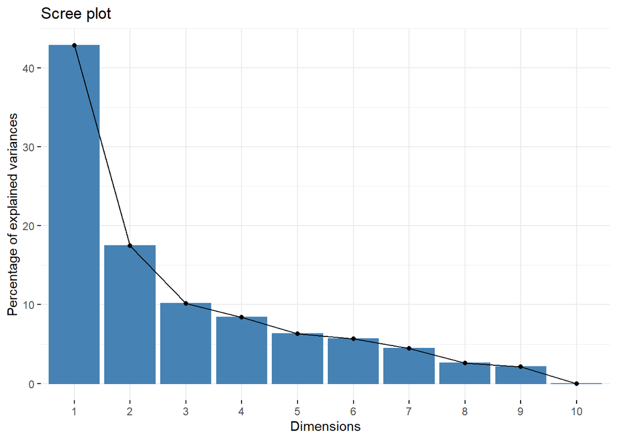

##We can visualize how each component formed up by different variables. However, the graph is very hard to see, not as easy to see as rotation report.

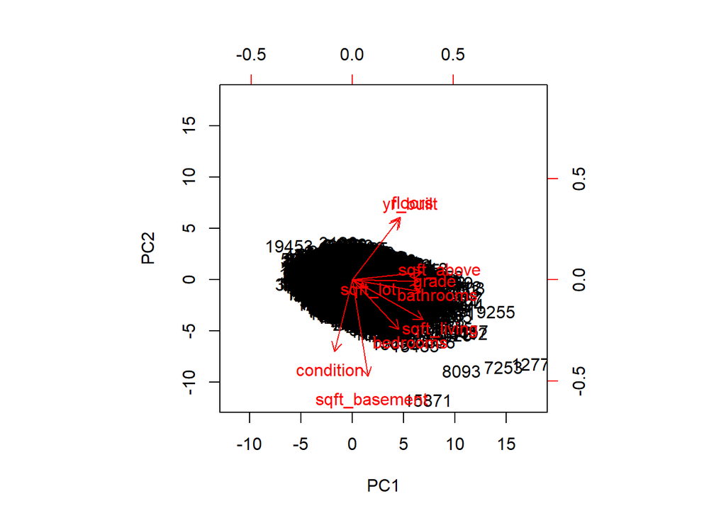

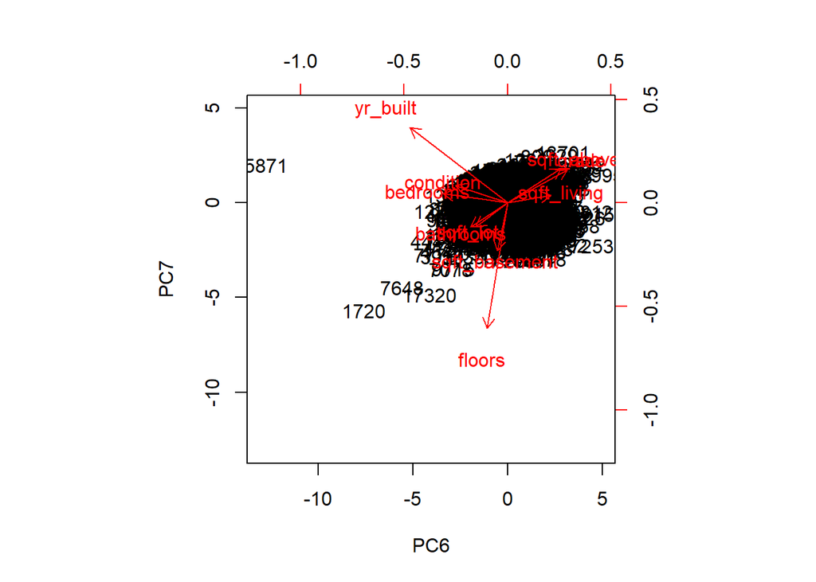

##Visulize the cumulative proportions of variance, we can see that after 7 components, the curve becomes smooth.

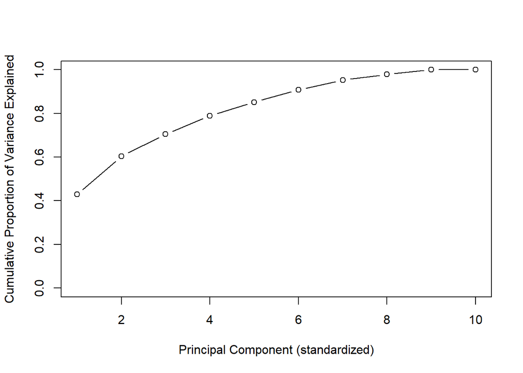

##Predicting use pca ##Finally, we can created a pcr model wth the 7 components. Actually, the PCR model is a linear model, so I used lm function to create it.

```
##
## Call:
## lm(formula = house2$price ~ houseprice[, 1:7])
##
## Residuals:
##      Min       1Q   Median       3Q      Max
## -1353938  -117818   -11744    91786  4213791
##
## Coefficients:
##                      Estimate Std. Error t value             Pr(>|t|)
## (Intercept)          540088.1     1553.7 347.624 < 0.0000000000000002 ***
## houseprice[, 1:7]PC1 109183.6      750.3 145.528 < 0.0000000000000002 ***
## houseprice[, 1:7]PC2 -78959.1     1174.8 -67.210 < 0.0000000000000002 ***
## houseprice[, 1:7]PC3  -9625.1     1543.3  -6.237       0.000000000455 ***
## houseprice[, 1:7]PC4 -37260.9     1696.4 -21.965 < 0.0000000000000002 ***
## houseprice[, 1:7]PC5 -58357.3     1960.2 -29.771 < 0.0000000000000002 ***
## houseprice[, 1:7]PC6 171525.8     2064.0  83.103 < 0.0000000000000002 ***
## houseprice[, 1:7]PC7 -34516.0     2324.9 -14.846 < 0.0000000000000002 ***
## ---
## Signif. codes:  0 '***' 0.001 '**' 0.01 '*' 0.05 '.' 0.1 ' ' 1
##
## Residual standard error: 228400 on 21605 degrees of freedom
## Multiple R-squared:  0.6131, Adjusted R-squared:  0.6129
## F-statistic:  4890 on 7 and 21605 DF,  p-value: < 0.00000000000000022
```

##We can see that there is 61.3% variance explained by the independent variable. I do not use accuracy as a scale to check whethere the model is good or not. The reason is that the difference between the house price is very large. So using accuracy to check the model is unreachable.

##I want to see how good the PCR model is, so I created a full linear model to compare.

```
##
## Call:
## lm(formula = price ~ . - sqft_basement, data = house2)
##
## Residuals:
##      Min       1Q   Median       3Q      Max
## -1330687  -116072   -12249    88891  4428176
##
## Coefficients:
##                  Estimate    Std. Error t value             Pr(>|t|)
## (Intercept) 6899404.91899  135999.64524  50.731 < 0.0000000000000002 ***
## bedrooms     -49150.75728    2112.14737 -23.271 < 0.0000000000000002 ***
## bathrooms     49461.37021    3632.59901  13.616 < 0.0000000000000002 ***
## sqft_living     203.68790       4.72387  43.119 < 0.0000000000000002 ***
## sqft_lot         -0.22165       0.03838  -5.775    0.000000007807256 ***
## floors        28958.52490    3915.46549   7.396    0.000000000000146 ***
## condition     18383.60660    2586.64540   7.107    0.000000000001222 ***
## grade        131536.39560    2251.97276  58.409 < 0.0000000000000002 ***
## sqft_above      -21.98999       4.61155  -4.768    0.000001868528280 ***
## yr_built      -3953.47499      69.78574 -56.652 < 0.0000000000000002 ***
## ---
## Signif. codes:  0 '***' 0.001 '**' 0.01 '*' 0.05 '.' 0.1 ' ' 1
##
## Residual standard error: 227100 on 21603 degrees of freedom
## Multiple R-squared:  0.6177, Adjusted R-squared:  0.6175
## F-statistic:  3878 on 9 and 21603 DF,  p-value: < 0.00000000000000022
```

##There is 61.8% variance explained by the independent variable in the full linear model. It is little better than the PCR model.

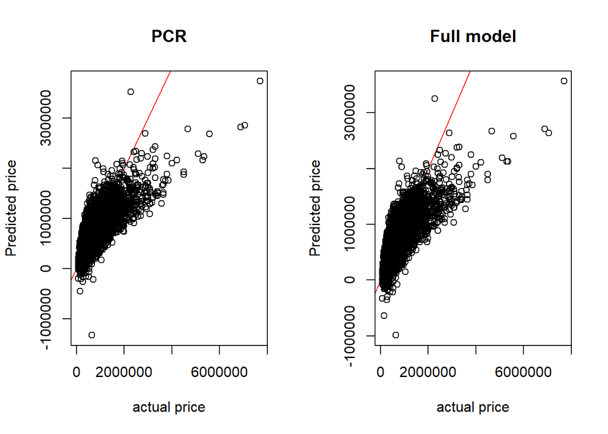

##Create a picture to compare the PCR model with the full linear model. ##R^2 of full model is 0.618 which is higher than pcr which is 0.613 ##we can see that both models underestimate the value of house price over 4e+06

# 5 Ridge and Lasso

We first load the dataset and remove columns that would be used in the regression. Then drop the NA values from the dataset.

```
##  [1] "id"            "date"          "price"         "bedrooms"
##  [5] "bathrooms"     "sqft_living"   "sqft_lot"      "floors"
##  [9] "waterfront"    "view"          "condition"     "grade"
## [13] "sqft_above"    "sqft_basement" "yr_built"      "yr_renovated"
## [17] "zipcode"       "lat"           "long"          "sqft_living15"
## [21] "sqft_lot15"
```

### 5.0.1 The Ridge

For our dataset, numbers of bedrooms, bathrooms, floors are categorical variables. So we transfer them into factors. Then we prepare log scale grid for λ values, from 10^10 to 10^-2, in 100 segments and build the ridge model. Afterwards, we draw plot of coefficients to see the overall trend.

```
## [1]  64 100
```

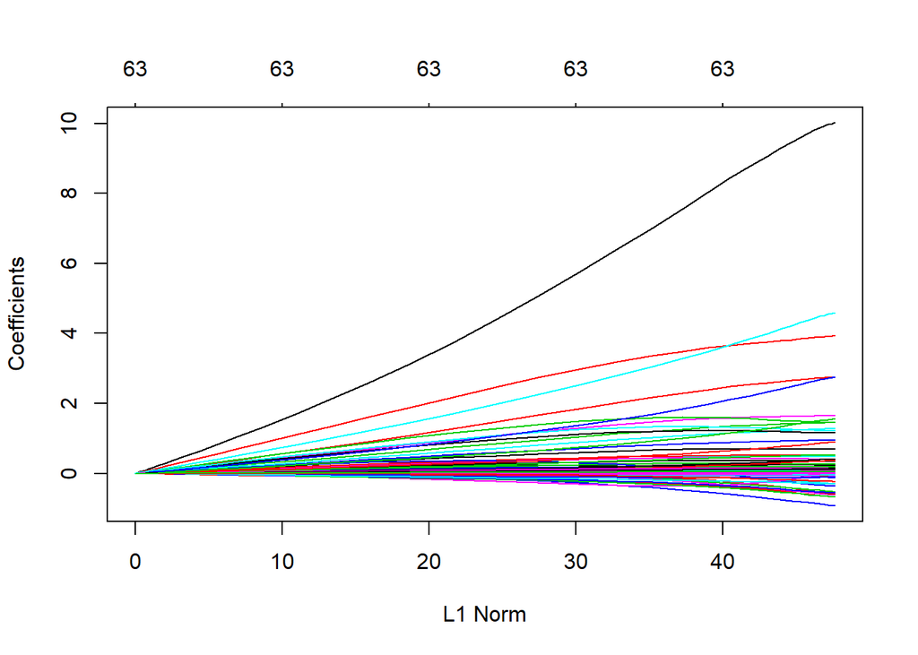

```
## [1] 11497.57
```

```
##      (Intercept)        bedrooms2        bedrooms3        bedrooms4
## -0.0000040980170 -0.0000376875226 -0.0000321328097  0.0000330920650
##        bedrooms5        bedrooms6        bedrooms7        bedrooms8
##  0.0000630224426  0.0000684280801  0.0000974909518  0.0001338580981
##        bedrooms9       bedrooms10       bedrooms11    bathrooms0.75
##  0.0000838030701  0.0000661073155 -0.0000047969188 -0.0000582705205
##       bathrooms1    bathrooms1.25     bathrooms1.5    bathrooms1.75
## -0.0000556557216  0.0000192042159 -0.0000331931765 -0.0000235345313
##       bathrooms2    bathrooms2.25     bathrooms2.5    bathrooms2.75
## -0.0000214045381 -0.0000017073853  0.0000042620588  0.0000300723562
##       bathrooms3    bathrooms3.25     bathrooms3.5    bathrooms3.75
##  0.0000412736296  0.0001047247118  0.0000960180636  0.0001567254894
##       bathrooms4    bathrooms4.25     bathrooms4.5    bathrooms4.75
##  0.0001733856475  0.0002342722620  0.0001887769859  0.0003511567564
##       bathrooms5    bathrooms5.25     bathrooms5.5    bathrooms5.75
##  0.0002686616855  0.0003026162067  0.0004696509966  0.0004624523001
##       bathrooms6    bathrooms6.25     bathrooms6.5    bathrooms6.75
##  0.0005701523301  0.0006048822676  0.0002769166910  0.0005196107787
##     bathrooms7.5    bathrooms7.75       bathrooms8      sqft_living
## -0.0000213895225  0.0015028460370  0.0010539840220  0.0000610292278
##         sqft_lot        floors1.5          floors2        floors2.5
##  0.0000078140248  0.0000048869510  0.0000416486779  0.0001241119778
##          floors3        floors3.5       condition2       condition3
##  0.0000105190518  0.0000876648420 -0.0000506120561  0.0000012698794
##       condition4       condition5           grade4           grade5
## -0.0000060750485  0.0000185675418 -0.0000778153322 -0.0000698539387
##           grade6           grade7           grade8           grade9
## -0.0000623051298 -0.0000557624616  0.0000008991541  0.0000628620810
##          grade10          grade11          grade12          grade13
##  0.0001328655611  0.0002308258176  0.0003950340059  0.0007510934666
##       sqft_above    sqft_basement         yr_built     yr_renovated
##  0.0000526331376  0.0000281518438  0.0000046872103  0.0000109929676
```

```
## [1] 0.002491064
```

```
## [1] 705.4802
```

```
##    (Intercept)      bedrooms2      bedrooms3      bedrooms4      bedrooms5
## -0.00006494817 -0.00060975790 -0.00052078121  0.00053548830  0.00102169182
##      bedrooms6      bedrooms7      bedrooms8      bedrooms9     bedrooms10
##  0.00110908994  0.00157892513  0.00217219150  0.00135760090  0.00107075236
##     bedrooms11  bathrooms0.75     bathrooms1  bathrooms1.25   bathrooms1.5
## -0.00008112621 -0.00094429990 -0.00090136514  0.00031387403 -0.00053793598
##  bathrooms1.75     bathrooms2  bathrooms2.25   bathrooms2.5  bathrooms2.75
## -0.00038130999 -0.00034704539 -0.00002800306  0.00006729977  0.00048685657
##     bathrooms3  bathrooms3.25   bathrooms3.5  bathrooms3.75     bathrooms4
##  0.00066887474  0.00169946642  0.00155692919  0.00254378918  0.00281382921
##  bathrooms4.25   bathrooms4.5  bathrooms4.75     bathrooms5  bathrooms5.25
##  0.00380316153  0.00306352789  0.00570328781  0.00436169610  0.00491402755
##   bathrooms5.5  bathrooms5.75     bathrooms6  bathrooms6.25   bathrooms6.5
##  0.00762671457  0.00750754119  0.00926261649  0.00982111982  0.00448970133
##  bathrooms6.75   bathrooms7.5  bathrooms7.75     bathrooms8    sqft_living
##  0.00843575670 -0.00035386298  0.02442904337  0.01711875027  0.00098994678
##       sqft_lot      floors1.5        floors2      floors2.5        floors3
##  0.00012647717  0.00008109612  0.00067350366  0.00201466240  0.00017185050
##      floors3.5     condition2     condition3     condition4     condition5
##  0.00142440165 -0.00082009386  0.00001897177 -0.00009736244  0.00030300076
##         grade4         grade5         grade6         grade7         grade8
## -0.00126098876 -0.00113239971 -0.00100971257 -0.00090431006  0.00001334554
##         grade9        grade10        grade11        grade12        grade13
##  0.00101881955  0.00215582981  0.00374673143  0.00641515728  0.01219920835
##     sqft_above  sqft_basement       yr_built   yr_renovated
##  0.00085287706  0.00045693832  0.00007419406  0.00017867435
```

```
## [1] 0.04046595
```

The model although only has 100 different values of $\lambda$ recorded, we can use the predict function (in R basic stats library) for various different purpose, such as gettint the predicted coefficients for $\lambda$=50, for example. e

```
##    (Intercept)      bedrooms2      bedrooms3      bedrooms4      bedrooms5
## -0.00061793601 -0.00769266980 -0.00677854369  0.00681632162  0.01340164259
##      bedrooms6      bedrooms7      bedrooms8      bedrooms9     bedrooms10
##  0.01447115976  0.02028500961  0.02900189174  0.01753995765  0.01377933342
##     bedrooms11  bathrooms0.75     bathrooms1  bathrooms1.25   bathrooms1.5
## -0.00192613971 -0.01232382731 -0.01164198574  0.00473657887 -0.00701925150
##  bathrooms1.75     bathrooms2  bathrooms2.25   bathrooms2.5  bathrooms2.75
## -0.00494564666 -0.00455068487 -0.00041880549  0.00049057058  0.00628025284
##     bathrooms3  bathrooms3.25   bathrooms3.5  bathrooms3.75     bathrooms4
##  0.00877162962  0.02276801235  0.02056079470  0.03418273369  0.03771442963
##  bathrooms4.25   bathrooms4.5  bathrooms4.75     bathrooms5  bathrooms5.25
##  0.05124965718  0.04104130153  0.07749689866  0.05884907912  0.06656172197
##   bathrooms5.5  bathrooms5.75     bathrooms6  bathrooms6.25   bathrooms6.5
##  0.10331130532  0.10113126025  0.12647032241  0.13259456578  0.05904439670
##  bathrooms6.75   bathrooms7.5  bathrooms7.75     bathrooms8    sqft_living
##  0.11370915834 -0.00629455658  0.33690967320  0.23254874826  0.01321086278
##       sqft_lot      floors1.5        floors2      floors2.5        floors3
##  0.00163110848  0.00148690599  0.00858044066  0.02724980223  0.00254842689
##      floors3.5     condition2     condition3     condition4     condition5
##  0.01954879112 -0.01080178075 -0.00008231321 -0.00106132367  0.00444301006
##         grade4         grade5         grade6         grade7         grade8
## -0.01668451268 -0.01507629452 -0.01338216022 -0.01206990136 -0.00002539736
```

### 5.0.2 Train and Test sets

Let us split the data into training and test set, so that we can estimate test errors. The split will be used here for Ridge and later for Lasso regression.

```
## [1] 0.5710491
```

The test set mean-squared-error MSE is 0.5710491 (remember that we are using standardized scores) for $\lambda = 4$.

```
## [1] 0.9778839
```

On the other hand, for the null model ($\lambda$ approach infinity), the test MSE can be found to be 0.9778839. So $\lambda = 4$ reduces the variance by about half at the expense of the bias.

```
## [1] 0.9778839
```

We could have also used a large $\lambda$ value to find the MSE for the null model. These two methods yield essentially the same answer of 0.9778839.

```
## [1] 0.3403113
```

```
##   (Intercept)     bedrooms2     bedrooms3     bedrooms4     bedrooms5
##   0.048184465   0.091706965  -0.047702324  -0.147633248  -0.127257586
##     bedrooms6     bedrooms7     bedrooms8     bedrooms9    bedrooms10
##  -0.295208145  -0.335460654  -0.291513368  -0.443920358  -0.383159302
##    bedrooms11 bathrooms0.75    bathrooms1 bathrooms1.25  bathrooms1.5
##  -0.975283188  -0.024469549  -0.047465592  -0.416523767  -0.053748157
## bathrooms1.75    bathrooms2 bathrooms2.25  bathrooms2.5 bathrooms2.75
##  -0.040963130  -0.040774266   0.014442645  -0.037590724  -0.007326548
##    bathrooms3 bathrooms3.25  bathrooms3.5 bathrooms3.75    bathrooms4
##   0.078019397   0.222074220   0.136234189   0.504827737   0.183597771
## bathrooms4.25  bathrooms4.5 bathrooms4.75    bathrooms5 bathrooms5.25
##   0.603695818   0.629504441   2.399201673   1.007286436   1.157188353
##  bathrooms5.5 bathrooms5.75    bathrooms6 bathrooms6.25  bathrooms6.5
##   2.225820206   2.059088284   1.960620601   3.910868009   0.298959299
## bathrooms6.75  bathrooms7.5 bathrooms7.75    bathrooms8   sqft_living
##   1.014333766   0.000000000   0.000000000   0.000000000   0.197865780
##      sqft_lot     floors1.5       floors2     floors2.5       floors3
##  -0.031667388   0.048103513   0.067198680   0.179232406   0.403640389
##     floors3.5    condition2    condition3    condition4    condition5
##   0.568292145  -0.037869538   0.002239275   0.053905387   0.200325654
##        grade4        grade5        grade6        grade7        grade8
##  -0.684432931  -0.702358037  -0.558702225  -0.292054791  -0.011545394
```

Now for the other extreme speical case of small $\lambda$, which is the ordinary least square (OLS) model. We can first use the ridge regression result to predict the $\lambda$ =0 case. The MSE found to be 0.3403113 that way.

We can also build the OLS model directly.

```
##
## Call:
## lm(formula = price ~ ., data = train)
##
## Residuals:
##     Min      1Q  Median      3Q     Max
## -5.4415 -0.2946 -0.0332  0.2290 11.8149
##
## Coefficients: (1 not defined because of singularities)
##                Estimate Std. Error t value             Pr(>|t|)
## (Intercept)   -1.147505   0.478328  -2.399             0.016457 *
## bedrooms2      0.021081   0.068505   0.308             0.758298
## bedrooms3     -0.122049   0.068607  -1.779             0.075275 .
## bedrooms4     -0.226023   0.069902  -3.233             0.001227 **
## bedrooms5     -0.206984   0.073130  -2.830             0.004658 **
## bedrooms6     -0.375729   0.088605  -4.240   0.0000224913062269 ***
## bedrooms7     -0.421311   0.154531  -2.726             0.006414 **
## bedrooms8     -0.372775   0.255782  -1.457             0.145037
## bedrooms9     -0.541173   0.353898  -1.529             0.126250
## bedrooms10    -0.469576   0.428409  -1.096             0.273063
## bedrooms11    -1.066352   0.601473  -1.773             0.076273 .
## bathrooms0.75  0.260123   0.438022   0.594             0.552619
## bathrooms1     0.252660   0.423029   0.597             0.550343
## bathrooms1.25 -0.147726   0.544811  -0.271             0.786281
## bathrooms1.5   0.247682   0.423820   0.584             0.558961
## bathrooms1.75  0.261476   0.423599   0.617             0.537067
## bathrooms2     0.262222   0.423755   0.619             0.536057
## bathrooms2.25  0.317442   0.423963   0.749             0.454025
## bathrooms2.5   0.266349   0.423940   0.628             0.529839
## bathrooms2.75  0.295872   0.424496   0.697             0.485820
## bathrooms3     0.381347   0.424860   0.898             0.369428
## bathrooms3.25  0.523158   0.425513   1.229             0.218920
## bathrooms3.5   0.437294   0.425401   1.028             0.303993
## bathrooms3.75  0.806447   0.429933   1.876             0.060717 .
## bathrooms4     0.481345   0.429683   1.120             0.262640
## bathrooms4.25  0.903343   0.434846   2.077             0.037790 *
## bathrooms4.5   0.932055   0.434070   2.147             0.031796 *
## bathrooms4.75  2.712091   0.471254   5.755   0.0000000088988964 ***
## bathrooms5     1.311540   0.463286   2.831             0.004650 **
## bathrooms5.25  1.455631   0.503019   2.894             0.003814 **
```

[output cut: 21 more lines]

```
## grade9         1.140774   0.147067   7.757   0.0000000000000095 ***
## grade10        1.635524   0.149350  10.951 < 0.0000000000000002 ***
## grade11        2.262675   0.155426  14.558 < 0.0000000000000002 ***
## grade12        3.392859   0.174565  19.436 < 0.0000000000000002 ***
## grade13        4.129846   0.304425  13.566 < 0.0000000000000002 ***
## sqft_above    -0.089739   0.015306  -5.863   0.0000000046825032 ***
## sqft_basement        NA         NA      NA                   NA
## yr_built      -0.239163   0.009270 -25.800 < 0.0000000000000002 ***
## yr_renovated   0.041271   0.006241   6.613   0.0000000000393945 ***
## ---
## Signif. codes:  0 '***' 0.001 '**' 0.01 '*' 0.05 '.' 0.1 ' ' 1
##
## Residual standard error: 0.5958 on 10739 degrees of freedom
## Multiple R-squared:  0.6548, Adjusted R-squared:  0.6529
## F-statistic: 351.2 on 58 and 10739 DF,  p-value: < 0.00000000000000022
```

```
## [1] 0.3530565
```

The MSE for OLS regression is 0.3530565

### 5.0.3 Use Cross-validation

We use a built-in cross-validation method with glmnet, which will select the minimal $\lambda$ value.

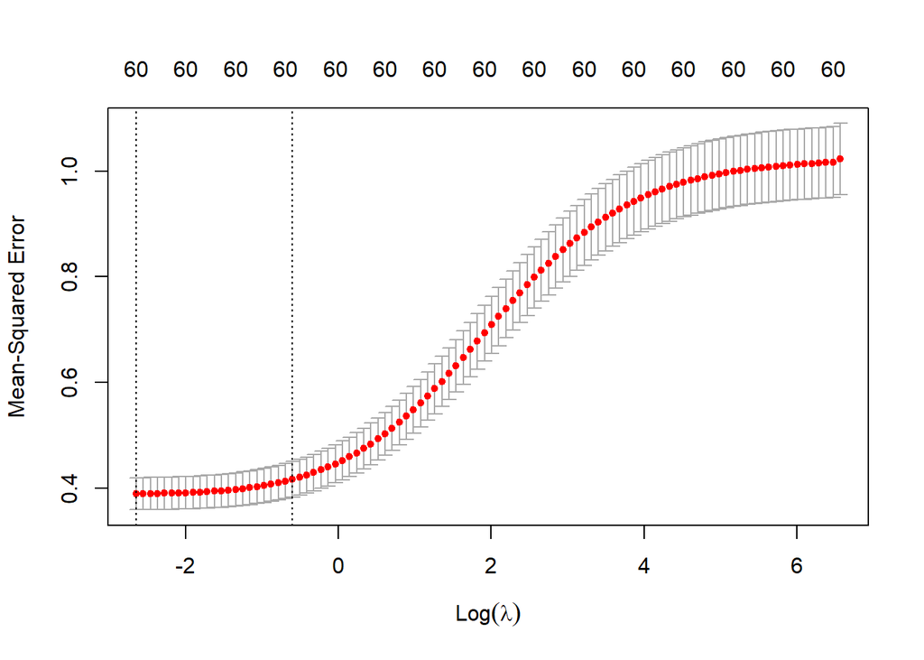

```
## [1] 0.07101001
```

```
## [1] 0.3422399
```

```
##   (Intercept)     bedrooms2     bedrooms3     bedrooms4     bedrooms5
##   0.043478852   0.121090195   0.004378733  -0.072231722  -0.069731013
##     bedrooms6     bedrooms7     bedrooms8     bedrooms9    bedrooms10
##  -0.228138822  -0.518880718   0.017358594  -0.457613338  -0.434305299
##    bedrooms11 bathrooms0.75    bathrooms1 bathrooms1.25  bathrooms1.5
##  -0.808463342  -0.005214896  -0.063739581   0.238327008  -0.055071212
## bathrooms1.75    bathrooms2 bathrooms2.25  bathrooms2.5 bathrooms2.75
##  -0.043473302  -0.046950974   0.005896216  -0.047982752   0.006371358
##    bathrooms3 bathrooms3.25  bathrooms3.5 bathrooms3.75    bathrooms4
##   0.063528286   0.272594246   0.139743650   0.480245326   0.415690245
## bathrooms4.25  bathrooms4.5 bathrooms4.75    bathrooms5 bathrooms5.25
##   0.698217426   0.520105152   1.428888437   0.937852810   1.244940214
##  bathrooms5.5 bathrooms5.75    bathrooms6 bathrooms6.25  bathrooms6.5
##   1.636202945   1.179701431   2.683794283   1.486592817  -0.274417942
## bathrooms6.75  bathrooms7.5 bathrooms7.75    bathrooms8   sqft_living
##   1.246170639  -0.116421187   9.609174025   3.844577523   0.194552698
##      sqft_lot     floors1.5       floors2     floors2.5       floors3
##  -0.025736135   0.068644258   0.062756225   0.354014116   0.328811595
##     floors3.5    condition2    condition3    condition4    condition5
##   0.509633343  -0.118893740  -0.050877918   0.017504797   0.143657894
##        grade4        grade5        grade6        grade7        grade8
##  -0.566168741  -0.582856690  -0.490163101  -0.277266146  -0.019318686
##        grade9       grade10       grade11       grade12       grade13
##   0.365242850   0.812648986   1.424332419   2.549729337   4.306752040
##    sqft_above sqft_basement      yr_built  yr_renovated
##   0.144039977   0.117953811  -0.200267674   0.045751849
```

```
## [1] 0.6499571
```

### 5.0.4 The Lasso

The same functino glmnet( ) with alpha set to 1 will build the Lasso regression model. Then draw the polt for different $\lambda$ values to see the overall trend.

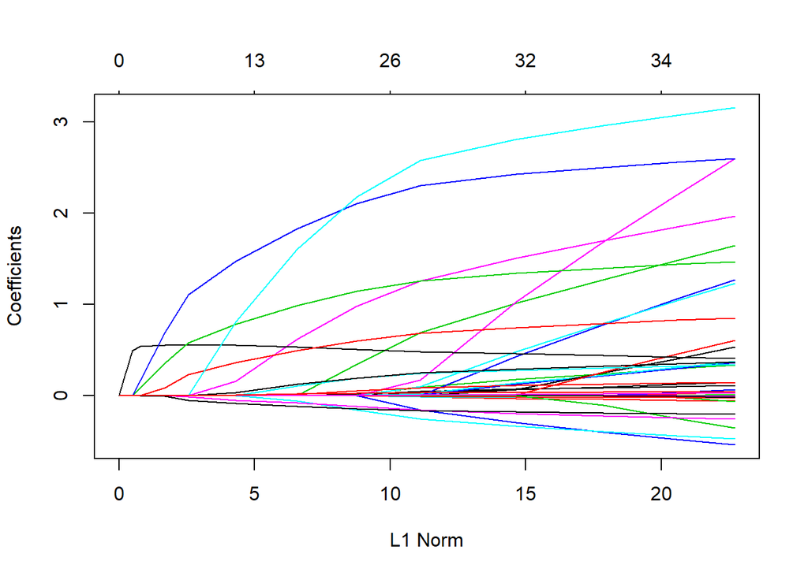

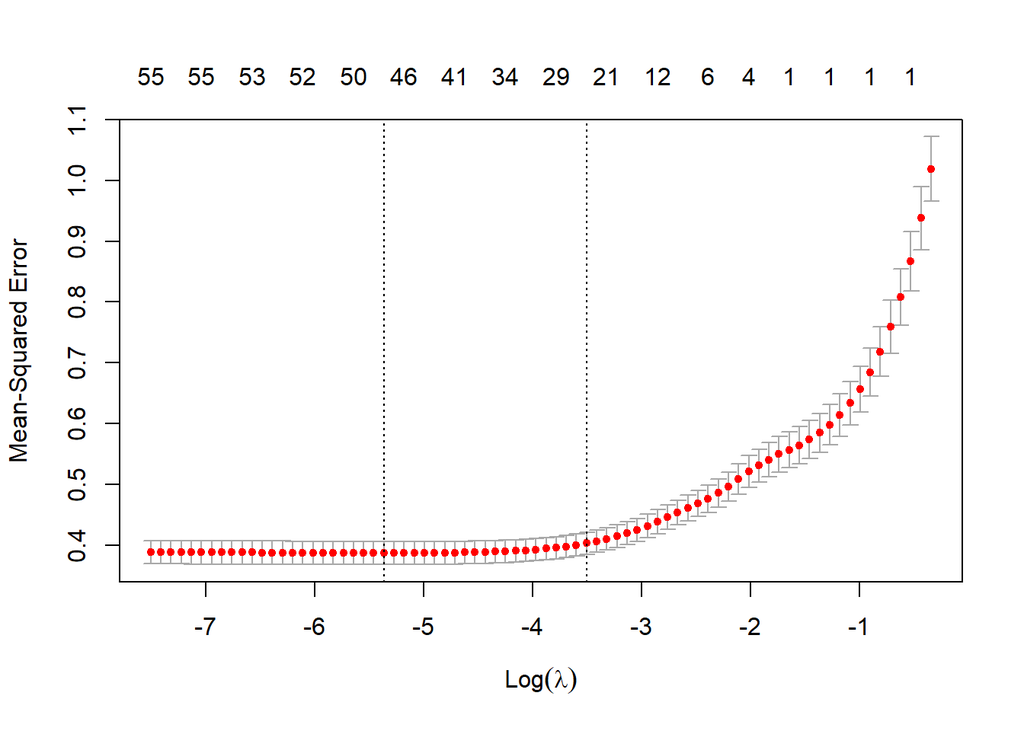

```
## [1] 0.3439372
```

```
##   (Intercept)     bedrooms2     bedrooms3     bedrooms4     bedrooms5
##   0.012861029   0.093595628   0.000000000  -0.048179870   0.000000000
##     bedrooms6     bedrooms7     bedrooms8     bedrooms9    bedrooms10
##  -0.071382235  -0.114500804   0.000000000   0.000000000   0.000000000
##    bedrooms11 bathrooms0.75    bathrooms1 bathrooms1.25  bathrooms1.5
##   0.000000000   0.000000000   0.000000000   0.000000000   0.000000000
## bathrooms1.75    bathrooms2 bathrooms2.25  bathrooms2.5 bathrooms2.75
##   0.000000000   0.000000000   0.000000000  -0.027100314   0.000000000
##    bathrooms3 bathrooms3.25  bathrooms3.5 bathrooms3.75    bathrooms4
##   0.000000000   0.184978033   0.032742843   0.296346706   0.182971228
## bathrooms4.25  bathrooms4.5 bathrooms4.75    bathrooms5 bathrooms5.25
##   0.428244169   0.237665420   0.990292508   0.468567399   0.679740087
##  bathrooms5.5 bathrooms5.75    bathrooms6 bathrooms6.25  bathrooms6.5
##   0.910518751   0.061035473   1.956097472   0.064911507   0.000000000
## bathrooms6.75  bathrooms7.5 bathrooms7.75    bathrooms8   sqft_living
##   0.000000000   0.000000000   8.021735343   2.245955222   0.393074487
##      sqft_lot     floors1.5       floors2     floors2.5       floors3
##  -0.018989097   0.002876851   0.023335364   0.226012242   0.312984921
##     floors3.5    condition2    condition3    condition4    condition5
##   0.010468798  -0.032385206  -0.030527019   0.000000000   0.118629845
##        grade4        grade5        grade6        grade7        grade8
##  -0.280647492  -0.512188563  -0.474151335  -0.260784740   0.000000000
##        grade9       grade10       grade11       grade12       grade13
##   0.378506201   0.857413977   1.522790860   2.721514676   4.686894195
##    sqft_above sqft_basement      yr_built  yr_renovated
##   0.000000000   0.029217891  -0.207446387   0.039236486
```

```
##   (Intercept)     bedrooms2     bedrooms4     bedrooms6     bedrooms7
##   0.012861029   0.093595628  -0.048179870  -0.071382235  -0.114500804
##  bathrooms2.5 bathrooms3.25  bathrooms3.5 bathrooms3.75    bathrooms4
##  -0.027100314   0.184978033   0.032742843   0.296346706   0.182971228
## bathrooms4.25  bathrooms4.5 bathrooms4.75    bathrooms5 bathrooms5.25
##   0.428244169   0.237665420   0.990292508   0.468567399   0.679740087
##  bathrooms5.5 bathrooms5.75    bathrooms6 bathrooms6.25 bathrooms7.75
##   0.910518751   0.061035473   1.956097472   0.064911507   8.021735343
##    bathrooms8   sqft_living      sqft_lot     floors1.5       floors2
##   2.245955222   0.393074487  -0.018989097   0.002876851   0.023335364
##     floors2.5       floors3     floors3.5    condition2    condition3
##   0.226012242   0.312984921   0.010468798  -0.032385206  -0.030527019
##    condition5        grade4        grade5        grade6        grade7
##   0.118629845  -0.280647492  -0.512188563  -0.474151335  -0.260784740
##        grade9       grade10       grade11       grade12       grade13
##   0.378506201   0.857413977   1.522790860   2.721514676   4.686894195
## sqft_basement      yr_built  yr_renovated
##   0.029217891  -0.207446387   0.039236486
```

```
## [1] 0.6482211
```

Then calculate the R square of lasso regression which is 0.6482211.

Lasso regression is also a good tool for features selection. So we build a linear model by using lasso to select variables.

```
##
## Call:
## lm(formula = price ~ bedrooms + bathrooms + sqft_living + sqft_lot +
##     floors + condition + grade + sqft_basement + yr_built + yr_renovated,
##     data = kc_house_data)
##
## Residuals:
##      Min       1Q   Median       3Q      Max
## -2297337  -107678   -12103    84167  4423367
##
## Coefficients:
##                    Estimate    Std. Error t value             Pr(>|t|)
## (Intercept)   5786132.60141  287169.25373  20.149 < 0.0000000000000002 ***
## bedrooms2        5000.79964   16364.12495   0.306             0.759916
## bedrooms3      -42266.04061   16372.64126  -2.582             0.009844 **
## bedrooms4      -77996.49545   16713.06117  -4.667 0.000003077696587062 ***
## bedrooms5      -79967.75320   17595.15768  -4.545 0.000005526726706166 ***
## bedrooms6     -145434.50489   21451.29327  -6.780 0.000000000012349563 ***
## bedrooms7     -261655.22812   39396.04023  -6.642 0.000000000031756185 ***
## bedrooms8      -55905.04186   62457.89292  -0.895             0.370752
## bedrooms9     -257155.11024   97573.23003  -2.636             0.008407 **
## bedrooms10    -228865.17819  125830.28766  -1.819             0.068950 .
## bedrooms11    -376317.84176  213834.18269  -1.760             0.078446 .
## bathrooms0.75  120775.39311  109765.06612   1.100             0.271210
## bathrooms1      96789.88218  106610.13086   0.908             0.363948
## bathrooms1.25  198630.35195  128075.28527   1.551             0.120943
## bathrooms1.5   100835.80443  106757.79655   0.945             0.344910
## bathrooms1.75  106680.61037  106699.14338   1.000             0.317406
## bathrooms2     106596.23945  106735.79854   0.999             0.317955
## bathrooms2.25  126046.47625  106764.43723   1.181             0.237773
## bathrooms2.5   107924.76232  106735.61877   1.011             0.311960
## bathrooms2.75  127022.20045  106878.55549   1.188             0.234661
## bathrooms3     148479.36032  106994.81338   1.388             0.165235
## bathrooms3.25  220325.37179  107135.61092   2.057             0.039745 *
## bathrooms3.5   171417.87749  107095.70880   1.601             0.109479
## bathrooms3.75  300179.55601  108209.01638   2.774             0.005541 **
## bathrooms4     270502.40834  108467.93472   2.494             0.012644 *
## bathrooms4.25  376695.21291  109667.63384   3.435             0.000594 ***
## bathrooms4.5   316003.65313  109134.86874   2.896             0.003789 **
## bathrooms4.75  656581.34980  116105.96865   5.655 0.000000015780486413 ***
```

[output cut: 26 more lines]

```
## grade8         308137.74264  215017.30032   1.433             0.151848
## grade9         465726.13022  215080.07265   2.165             0.030371 *
## grade10        645649.15161  215182.10271   3.000             0.002699 **
## grade11        892622.01579  215462.45344   4.143 0.000034437130902824 ***
## grade12       1337778.96140  216619.34216   6.176 0.000000000670445142 ***
## grade13       2017629.01555  225570.44512   8.945 < 0.0000000000000002 ***
## sqft_basement      37.93024       4.65292   8.152 0.000000000000000378 ***
## yr_built        -3014.37761      79.91953 -37.718 < 0.0000000000000002 ***
## yr_renovated       36.26019       3.88856   9.325 < 0.0000000000000002 ***
## ---
## Signif. codes:  0 '***' 0.001 '**' 0.01 '*' 0.05 '.' 0.1 ' ' 1
##
## Residual standard error: 212900 on 21533 degrees of freedom
## Multiple R-squared:  0.6647, Adjusted R-squared:  0.6638
## F-statistic: 688.6 on 62 and 21533 DF,  p-value: < 0.00000000000000022
```

```
##     bedrooms2     bedrooms3     bedrooms4     bedrooms5     bedrooms6
##     14.223872     31.674561     28.899607     10.125899      2.726962
##     bedrooms7     bedrooms8     bedrooms9    bedrooms10    bedrooms11
##      1.299068      1.118315      1.260085      1.047947      1.008886
## bathrooms0.75    bathrooms1 bathrooms1.25  bathrooms1.5 bathrooms1.75
##     18.813271    793.562223      3.256117    339.076868    657.429717
##    bathrooms2 bathrooms2.25  bathrooms2.5 bathrooms2.75    bathrooms3
##    441.802390    466.047443   1015.119954    282.291820    183.575689
## bathrooms3.25  bathrooms3.5 bathrooms3.75    bathrooms4 bathrooms4.25
##    145.104721    178.736980     39.759246     35.083740     20.888164
##  bathrooms4.5 bathrooms4.75    bathrooms5 bathrooms5.25  bathrooms5.5
##     26.158885      6.834110      6.322537      4.323821      3.595639
## bathrooms5.75    bathrooms6 bathrooms6.25  bathrooms6.5 bathrooms6.75
##      2.066364      2.589318      1.565405      1.518451      1.539934
##  bathrooms7.5 bathrooms7.75    bathrooms8   sqft_living      sqft_lot
##      1.456925      1.361406      1.619007      5.878199      1.073798
##     floors1.5       floors2     floors2.5       floors3     floors3.5
##      1.283892      2.643067      1.079936      1.272029      1.018015
##    condition2    condition3    condition4    condition5        grade4
##      6.853371    172.973304    147.240630     55.758410     28.132884
##        grade5        grade6        grade7        grade8        grade9
##    244.313360   1881.566198   5348.360213   4449.503417   2345.987219
##       grade10       grade11       grade12       grade13 sqft_basement
##   1097.761358    401.166821     91.769595     14.586600      2.021528
##      yr_built  yr_renovated
##      2.626251      1.163388
```

```
##
## Call:
## lm(formula = price ~ bedrooms + bathrooms + sqft_living + sqft_lot +
##     floors + grade + sqft_basement + yr_built + yr_renovated,
##     data = kc_house_data)
##
## Residuals:
##      Min       1Q   Median       3Q      Max
## -2299861  -107724   -11657    84378  4411029
##
## Coefficients:
##                    Estimate    Std. Error t value             Pr(>|t|)
## (Intercept)   6390398.78259  281343.40470  22.714 < 0.0000000000000002 ***
## bedrooms2        8793.15547   16411.38204   0.536             0.592105
## bedrooms3      -36077.63352   16412.82873  -2.198             0.027950 *
## bedrooms4      -71532.75656   16754.29106  -4.270 0.000019673362174609 ***
## bedrooms5      -74411.16227   17640.41670  -4.218 0.000024724450361411 ***
## bedrooms6     -142953.76147   21515.00232  -6.644 0.000000000031177874 ***
## bedrooms7     -258423.20806   39524.73870  -6.538 0.000000000063631652 ***
## bedrooms8      -55473.95759   62666.84195  -0.885             0.376048
## bedrooms9     -278523.92146   97883.13967  -2.845             0.004439 **
## bedrooms10    -227727.69953  126239.85681  -1.804             0.071256 .
## bedrooms11    -383449.72395  214555.70737  -1.787             0.073922 .
## bathrooms0.75  130401.26593  110127.99463   1.184             0.236391
## bathrooms1     101396.61064  106966.19136   0.948             0.343175
## bathrooms1.25  214387.12419  128495.13220   1.668             0.095242 .
## bathrooms1.5   109925.90550  107111.69437   1.026             0.304774
## bathrooms1.75  118404.44151  107051.35319   1.106             0.268716
## bathrooms2     119919.42404  107086.11730   1.120             0.262794
## bathrooms2.25  139025.11526  107115.63815   1.298             0.194336
## bathrooms2.5   120305.10659  107087.12309   1.123             0.261267
## bathrooms2.75  142766.29798  107227.26714   1.331             0.183060
## bathrooms3     161875.06297  107346.09858   1.508             0.131576
## bathrooms3.25  234468.41012  107486.78018   2.181             0.029167 *
## bathrooms3.5   183845.21888  107447.53005   1.711             0.087091 .
## bathrooms3.75  313888.27292  108564.32991   2.891             0.003841 **
## bathrooms4     285206.20490  108822.57541   2.621             0.008778 **
## bathrooms4.25  391992.63284  110026.50617   3.563             0.000368 ***
## bathrooms4.5   330613.42078  109491.82108   3.020             0.002535 **
## bathrooms4.75  670750.45800  116488.17113   5.758 0.000000008622312126 ***
```

[output cut: 22 more lines]

```
## grade8         258817.87233  215692.06066   1.200             0.230175
## grade9         416117.10729  215755.06873   1.929             0.053787 .
## grade10        594836.10597  215856.68975   2.756             0.005862 **
## grade11        840338.30560  216135.21633   3.888             0.000101 ***
## grade12       1285016.84723  217296.07248   5.914 0.000000003396224080 ***
## grade13       1959427.70483  226272.22087   8.660 < 0.0000000000000002 ***
## sqft_basement      40.31225       4.66300   8.645 < 0.0000000000000002 ***
## yr_built        -3295.58738      76.19239 -43.253 < 0.0000000000000002 ***
## yr_renovated       28.45761       3.83637   7.418 0.000000000000123452 ***
## ---
## Signif. codes:  0 '***' 0.001 '**' 0.01 '*' 0.05 '.' 0.1 ' ' 1
##
## Residual standard error: 213600 on 21537 degrees of freedom
## Multiple R-squared:  0.6624, Adjusted R-squared:  0.6615
## F-statistic: 728.6 on 58 and 21537 DF,  p-value: < 0.00000000000000022
```

[output not shown]

The R square is 0.6615003 which is better than ridge and lasso regression.